# Project: Investigate a Dataset (TMDb Movie Dataset)

Introduction

Creating a Copy of The Dataset

Making a Copy of The Dataset

Data Cleaning

Exporting the Cleaned Data to a New CSV

Exploratory Data Analysis

Visual Trends

Conclusion

## Introduction

This dataset contains information about over 10,000 movies collected from the movie database (TMDB), which was collected between 1960 and 2015, with information such as title, budget, revenue, cast, director, genres, release date, release year, runtime, etc. Certain columns, like ‘cast’ and ‘genres’, contain multiple values separated by pipe (|) characters.

The primary goals of the project include data collation and exploratory data analysis . This project uses Python's Pandas library to evaluate and clean data for fast visualization and exploration through the built-in functions of Pandas in data analysis and, finally, by descriptive statistics Matplotlib to visualize the results.

- Question 1. What are the top 20 movies based on their popularity?
- Question 2: How do movie budgets and profits compare? Does a high budget equal a high profit?
- Question 3. What is the relationship between the popularity and the runtime of movies?
- Question 4. The top 10 actors? What is the movie title, average vote count and the revenue generated?
- Question 5. Which genre has the highest release of movies?
- Question 9. Which Month Released The Highest Number Of Movies In All Of The Years? And which month made the highest average revenue?

## Exploratory Data Analysis

## Visual Trends

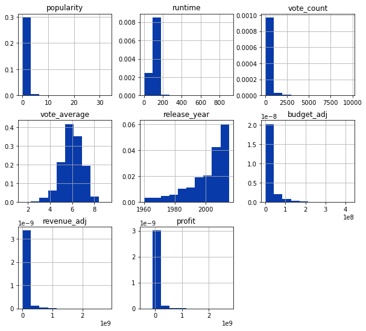

### Question 1. What are the top 20 movies based on their popularity?

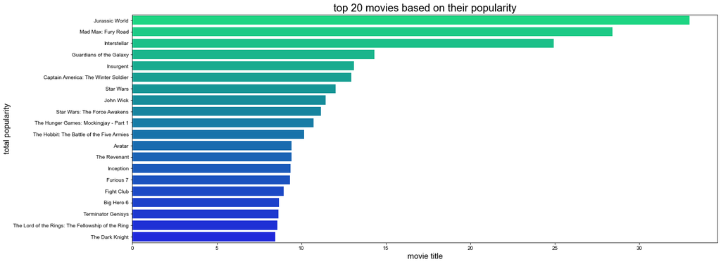

- From the chart above, it can be seen that Jurassic world movie has the highest popularity follwed by Mad Max etc

### Question 3: How do movies budgets and profits compare? Does a high budget equal a high profit?

[interactive chart not shown]

A positive correlation exists between a decent budget which in turn generates a good profit. Profit and budget have a positive correlation, so there is a good chance that movies with higher investments will result in higher profits.

### Question 5. What is the relationship between the popularity and the runtime of movies?

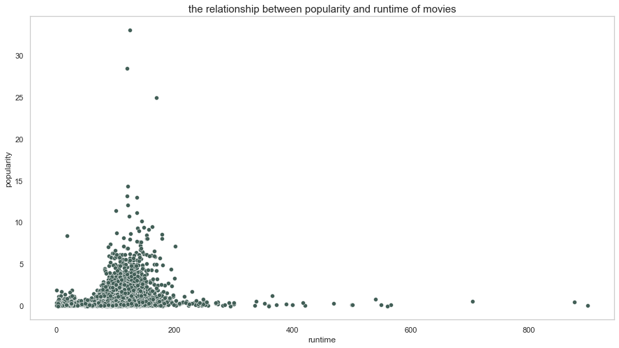

According to the plot, we can say that movies in the range of 100–200 runtime are more popular, while movies above the runtime of 200 minutes generally have decreased popularity. This is because long-running movies get boring and unexciting.

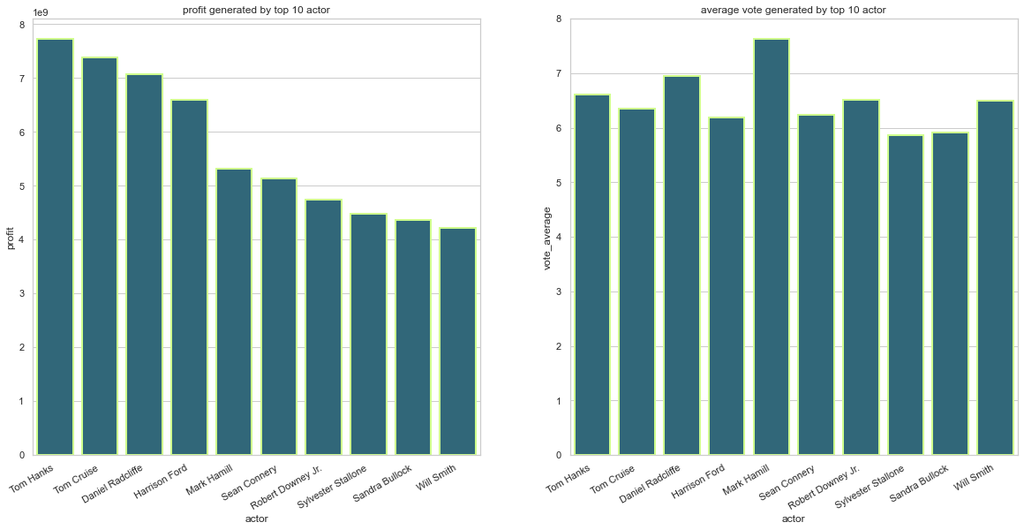

### Question 8. Which genre has the highest release of movies?

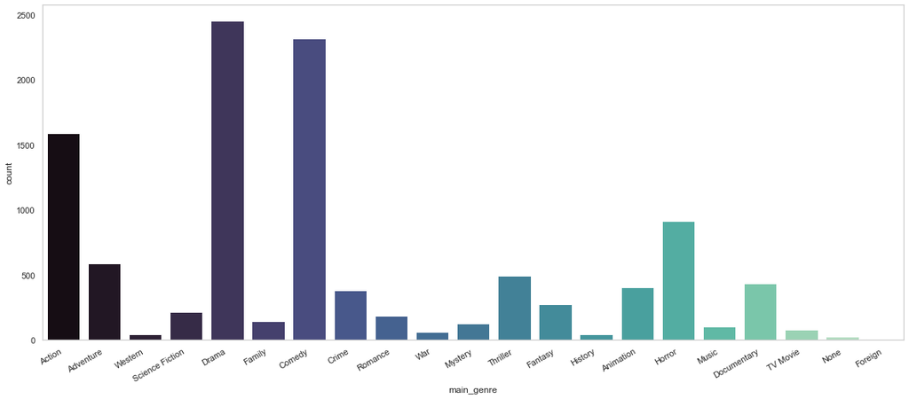

According to the above analysis, drama is the most popular genre when compared to other categories, followed by comedy, action, and horror.

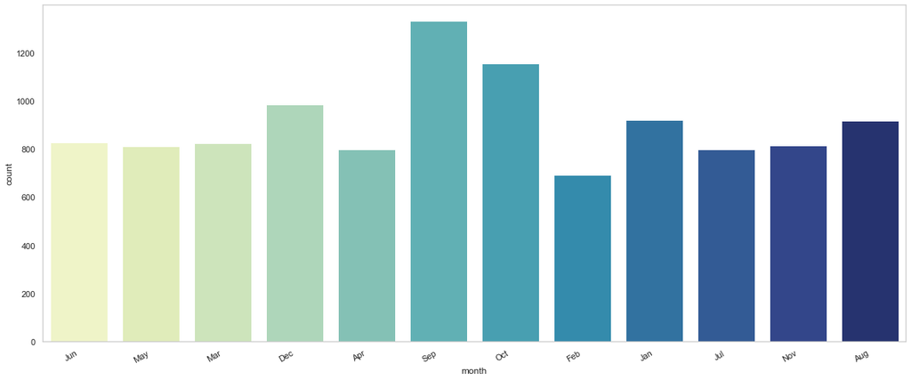

From the plot trend, we can conclude that there are a higher number of movies released in September and in October.